# PCIT-CoS-Waitlist RCT Paper 1: CBCL Externalising

Nancy Briggs

05 JAN 2021

### CBCL Externalising

#### Descriptives

| group | time | n | mean | sd | median | min | max |
| --- | --- | --- | --- | --- | --- | --- | --- |
| 1 | 1 | 30 | 20.099 | 10.501 | 19.935 | 2.000 | 41.739 |
| 1 | 2 | 23 | 13.013 | 8.411 | 10.000 | 3.000 | 35.000 |
| 1 | 3 | 18 | 14.258 | 9.887 | 13.000 | 1.000 | 39.652 |
| 2 | 1 | 28 | 24.095 | 8.667 | 23.000 | 9.000 | 41.000 |
| 2 | 2 | 13 | 19.396 | 9.965 | 18.000 | 6.545 | 40.000 |
| 2 | 3 | 5 | 15.600 | 3.507 | 16.000 | 12.000 | 21.000 |
| 3 | 1 | 26 | 19.763 | 9.451 | 20.720 | 3.000 | 38.000 |
| 3 | 2 | 22 | 18.104 | 8.831 | 18.000 | 5.000 | 40.000 |
| 3 | 3 | 0 | NaN | NA | NA | Inf | -Inf |

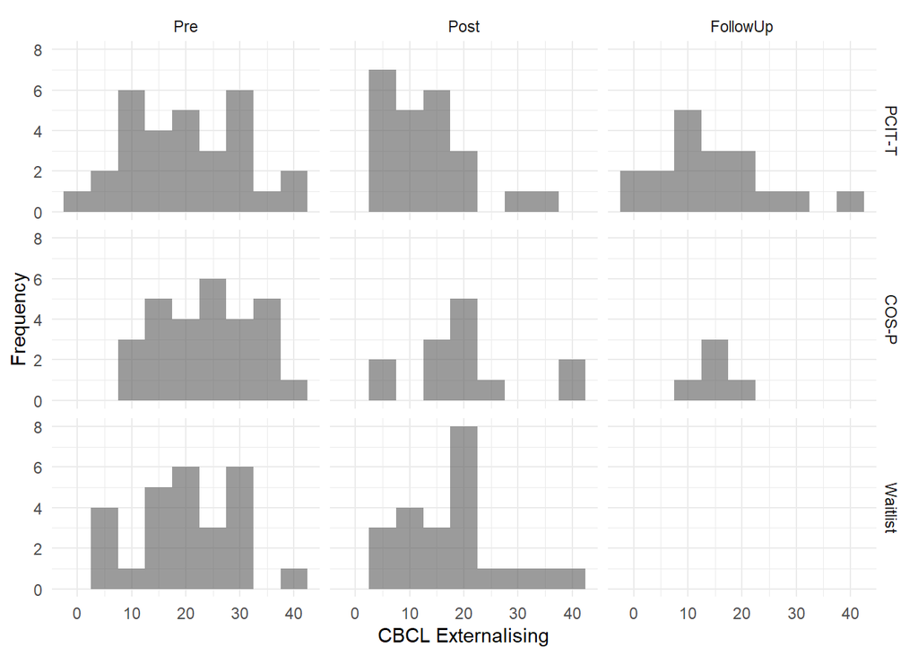

#### Model & Results

A linear mixed model with random effect for individual and fixed effects of group, time and the interaction was run. Estimated marginal means were obtained, and contrasts specified to test Hypothesis 1 and Hypothesis 2.

```
## fixed-effect model matrix is rank deficient so dropping 1 column / coefficient
```

This is the ANOVA table for the model. p-values are likelihood ratio tests for adding the new term to the model just before. A p-value <0.05 indicates that adding that term results in better model fit. The most important p-value is the interaction p-value. Here, there is no evidence that the pattern of change over time is different between the groups (p=0.591).

```
## refitting model(s) with ML (instead of REML)
```

|  | Effect | npar | AIC | BIC | logLik | deviance | Chisq | Df | Pr(>Chisq) |
| --- | --- | --- | --- | --- | --- | --- | --- | --- | --- |
| result0 | Intercept | 3 | 1179.966 | 1189.284 | -586.983 | 1173.966 | NA | NA | NA |
| result1 | Group | 5 | 1178.663 | 1194.192 | -584.331 | 1168.663 | 5.303 | 2 | 0.071 |
| result2 | Time | 7 | 1156.063 | 1177.805 | -571.032 | 1142.063 | 26.599 | 2 | 0.000 |
| result3 | Group*Time | 10 | 1160.154 | 1191.213 | -570.077 | 1140.154 | 1.909 | 3 | 0.591 |

```r
summary(result3)
```

```
## Linear mixed model fit by REML. t-tests use Satterthwaite's method [
## lmerModLmerTest]
## Formula: outcome ~ group * time + (1 | id)
##    Data: dat
##
## REML criterion at convergence: 1116.9
##
## Scaled residuals:
##     Min      1Q  Median      3Q     Max
## -1.9040 -0.4694 -0.0594  0.5168  2.1222
##
## Random effects:
##  Groups   Name        Variance Std.Dev.
##  id       (Intercept) 61.93    7.87
##  Residual             26.11    5.11
## Number of obs: 165, groups:  id, 85
##
## Fixed effects:
##              Estimate Std. Error       df t value Pr(>|t|)
## (Intercept)   20.0986     1.7132 102.5707  11.732  < 2e-16 ***
## group2         3.9968     2.4657 102.5707   1.621 0.108094
## group3         0.2810     2.5019 104.0352   0.112 0.910779
## time2         -5.9322     1.4760  78.3395  -4.019 0.000133 ***
## time3         -4.9532     1.6203  79.3389  -3.057 0.003047 **
## group2:time2   0.5537     2.4243  83.2810   0.228 0.819881
## group3:time2   2.7650     2.1385  78.7698   1.293 0.199795
## group2:time3  -0.3823     3.2962  83.7134  -0.116 0.907956
## ---
## Signif. codes:  0 '***' 0.001 '**' 0.01 '*' 0.05 '.' 0.1 ' ' 1
##
## Correlation of Fixed Effects:
##             (Intr) group2 group3 time2  time3  grp2:2 grp3:2
## group2      -0.695
## group3      -0.685  0.476
## time2       -0.344  0.239  0.236
## time3       -0.314  0.218  0.215  0.424
## group2:tim2  0.210 -0.302 -0.144 -0.609 -0.258
## group3:tim2  0.238 -0.165 -0.357 -0.690 -0.293  0.420
## group2:tim3  0.154 -0.222 -0.106 -0.208 -0.492  0.338  0.144
## fit warnings:
## fixed-effect model matrix is rank deficient so dropping 1 column / coefficient
```

#### Estimated Means & Change

Estimated means for each Treatment and Time are presented. In addition, within-group change between time points is presented with 95% CIs.

##### Group mean difference at each timepoint

Group Differences at Each Time Point

[output not shown]

* Effect size scaled by pooled T1 SD  
† ES 95% Bootstrapped Percentile CI limits  
‡ If you want a positive ES (and it is calculated as negative), be sure to switch the signs and positions of the lower and upper CIs.

##### Change within each group

Within-Group Change and Effect Sizes

[output not shown]

* Effect size scaled by pooled T1 SD  
† ES 95% Bootstrapped Percentile CI limits  
‡ If you want a positive ES (and it is calculated as negative), be sure to switch the signs and positions of the lower and upper CIs.

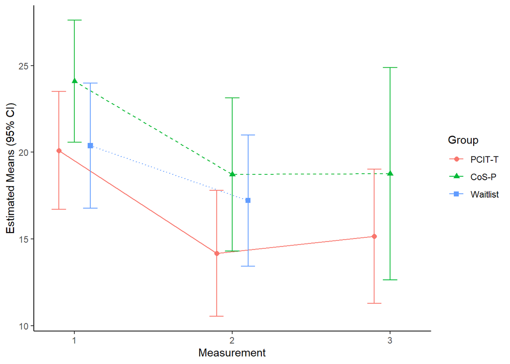

#### Hypothesis 1

We hypothesize that from baseline (‘T1’) to post-treatment/waitlist (‘T2’) there will be a gradient effect, whereby parent-child dyads who receive PCIT-T will show the greatest gains and parent-child dyads who receive no treatment will show the least gains. For the outcome, then, the null hypothesis is:

$H_0: \text {mean change}(\text{PCIT-T}) = \text {mean change}(\text{CoS-P}) = \text {mean change}(\text{Waitlist})$ $H_A: \text {mean change}(\text{PCIT-T}) > \text {mean change}(\text{CoS-P}) > \text {mean change}(\text{Waitlist})$

This is a joint hypothesis test.

First, confirming that the ordering of the means is as hypothesized:

```
## group = 1:
##  contrast estimate   SE   df t.ratio p.value
##  1 - 2      5.9322 1.48 80.0   4.014  0.0004
##  1 - 3      4.9532 1.62 81.0   3.052  0.0085
##  2 - 3     -0.9791 1.67 78.0  -0.587  0.8274
##
## group = 2:
##  contrast estimate   SE   df t.ratio p.value
##  1 - 2      5.3785 1.93 87.9   2.787  0.0177
##  1 - 3      5.3354 2.88 86.8   1.853  0.1589
##  2 - 3     -0.0431 2.93 80.9  -0.015  0.9999
##
## group = 3:
##  contrast estimate   SE   df t.ratio p.value
##  1 - 2      3.1672 1.55 80.8   2.044  0.1084
##  1 - 3      nonEst   NA   NA      NA      NA
##  2 - 3      nonEst   NA   NA      NA      NA
##
## Degrees-of-freedom method: kenward-roger
## P value adjustment: tukey method for comparing a family of 3 estimates
```

Now, to get the p-value associated with the joint hypothesis.

```
##   (Intercept) group2 group3 time2 time3 group2:time2 group3:time2 group2:time3
## 1           0      0      0     0     0           -1            0            0
## 2           0      0      0     0     1            0            1            0
```

```
##
##   General Linear Hypotheses
##
## Linear Hypotheses:
##        Estimate
## 1 == 0  -0.5537
## 2 == 0  -2.1882
##
## Global Test:
##        F DF1 DF2 Pr(>F)
## 1 0.5606   2 155  0.572
```

PCITT Change=5.9 > COSP change=5.4 > Waitlist change=3.16

So, the mean change for PCITT > COSP > Waitlist, but the pvalue>0.05. We fail to reject Hypothesis 1.

#### Hypothesis 2

##### Change from T2-T3

There will be a gradient of size of change from T2 to T3 such that the change in the PCIT-T group > the change in the CoS-P group. This isn’t really a gradient; it’s just 1 hypothesis.

First, the change in PCITT and COSP from time 2 to time 3:

```
## group = 1:
##  time emmean   SE  df lower.CL upper.CL
##  1      20.1 1.71 104     16.7     23.5
##  2      14.2 1.84 123     10.5     17.8
##  3      15.1 1.96 139     11.3     19.0
##
## group = 2:
##  time emmean   SE  df lower.CL upper.CL
##  1      24.1 1.77 104     20.6     27.6
##  2      18.7 2.24 152     14.3     23.1
##  3      18.8 3.09 141     12.6     24.9
##
## group = 3:
##  time emmean   SE  df lower.CL upper.CL
##  1      20.4 1.82 107     16.8     24.0
##  2      17.2 1.91 119     13.4     21.0
##  3    nonEst   NA  NA       NA       NA
##
## Degrees-of-freedom method: kenward-roger
## Confidence level used: 0.95
```

```
## group = 1:
##  contrast estimate   SE   df lower.CL upper.CL
##  1 - 2      5.9322 1.48 80.0    2.403     9.46
##  1 - 3      4.9532 1.62 81.0    1.078     8.83
##  2 - 3     -0.9791 1.67 78.0   -4.963     3.00
##
## group = 2:
##  contrast estimate   SE   df lower.CL upper.CL
##  1 - 2      5.3785 1.93 87.9    0.778     9.98
##  1 - 3      5.3354 2.88 86.8   -1.532    12.20
##  2 - 3     -0.0431 2.93 80.9   -7.040     6.95
##
## group = 3:
##  contrast estimate   SE   df lower.CL upper.CL
##  1 - 2      3.1672 1.55 80.8   -0.533     6.87
##  1 - 3      nonEst   NA   NA       NA       NA
##  2 - 3      nonEst   NA   NA       NA       NA
##
## Degrees-of-freedom method: kenward-roger
## Confidence level used: 0.95
## Conf-level adjustment: tukey method for comparing a family of 3 estimates
```

```r
## Specify contrast matrices
# Hyp1 is 1 df test
# could use alternative="less" ir alternative="greater" in glht
hyp2   <- matrix(c(0, 0,0, 0,0, -1,0,1 ),1)
hyp2F <- glht(result3, linfct = hyp2)
summary(hyp2F)
```

```
##
##   Simultaneous Tests for General Linear Hypotheses
##
## Fit: lmer(formula = outcome ~ group * time + (1 | id), data = dat)
##
## Linear Hypotheses:
##        Estimate Std. Error z value Pr(>|z|)
## 1 == 0   -0.936      3.367  -0.278    0.781
## (Adjusted p values reported -- single-step method)
```

```r
s<-summary(hyp2F, test = Ftest())
#also see this webpage for more on contrasts https://rcompanion.org/rcompanion/h_01.html



## Extract pvaue for evidence / no evidence
evidence = ifelse(s$test$pvalue<0.05, "evidence", "no evidence")
```

Change in G1 from T2 to T3: -0.979

Change in G2 from T2 to T3: -0.043

##### Change from T1-T3

```
##
##   General Linear Hypotheses
##
## Linear Hypotheses:
##        Estimate
## 1 == 0  -0.3823
##
## Global Test:
##         F DF1 DF2 Pr(>F)
## 1 0.01345   1 155 0.9078
```

Change in G1 from T1 to T3: 4.953

Change in G2 from T1 to T3: 5.335

p=0.9078. We have no evidence that the change from T1 to T3 is different for G1 and G2

#### Residuals

Assumptions of the model are met.

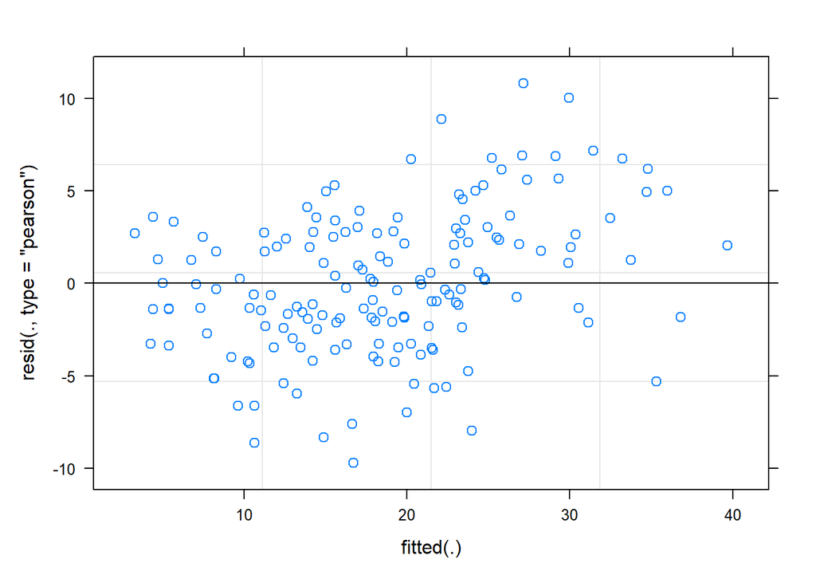

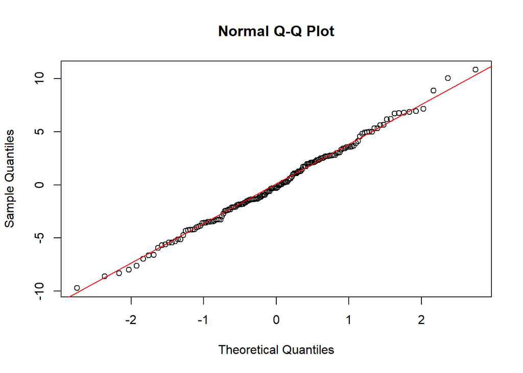

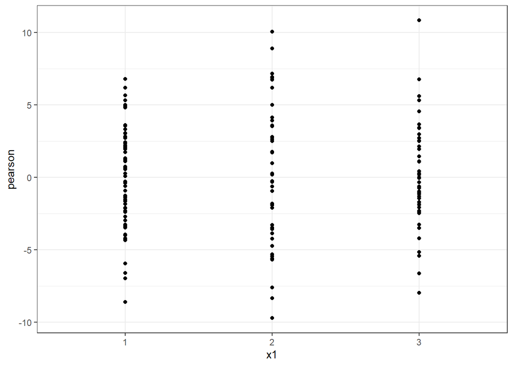

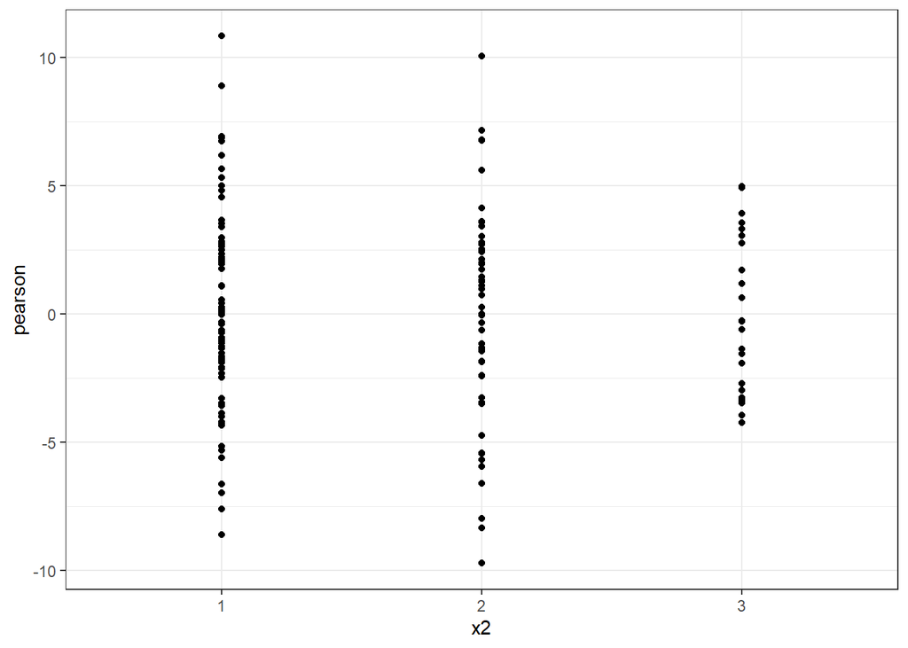

```r
rm(list = ls())
```